# Summarizing Quantitative Variables

Day 5

Claire Kelling

Carleton College  
STAT 120 - Fall 2026

## Question of the Day

What’s a food combination that you love?

## Today’s Topics

Logistics:

- First R Homework due on Friday! (start early!)
- Short Report partner preferences due Friday!
- Use code that we covered in class for homeworks/assignments
- Updates on Slack questions: updated template!

Topics covered today:

- Some notes on R
- Quantitative Variables (Section 2.2-2.4)
- Working with quantitative variables in R

## Comments in R

**Comments** are a tool in R for you to take notes on your functions and to let me (the reader) know what you are doing

Include your answers to HW questions *outside of code.*

```r
library(dplyr) #load the package

mean(mtcars$mpg)
```

```
[1] 20.09062
```

```r
#not running this line
#mean(mtcars$mpg)
```

**Case-sensitive:** The Mean() function is not the same as mean()

- Mean() won’t work!
- The object Mtcars is not the same as mtcars

## Nice output in R Markdown

You can create nice output in RMarkdown using the **knitr** package and the **kable()** function.

- What are R packages? (eg. knitr, ggplot, dplyr)
- How do I use them? (library(knitr))

```r
library(knitr)
kable(slice(jurors, 1,2))
```

| trial__id | race | struck_state | defendant_race | same_race | struck_by |
| --- | --- | --- | --- | --- | --- |
| 4 | Black | Not struck by State | White | different race | Juror chosen to serve on jury |
| 4 | Black | Struck by State | White | different race | Struck by the state |

# Quantitative Variables

## Describing Quantitative Variables

**Numerically:**

Interested in measures of

- “**Center**”: what is a middle/common value?
  - common measures: mean, median
- **“Variability”**: how spread out are values?
  - common measures: standard deviation, IQR, range
- **“Shape”**: how are values distributed around the “middle”?
  - common measure: 5-number summary

## Exercise: Low and High Variability

- What is a high variability “outcome” for this class?
- What is a low variability “outcome” for this class?

## Describing Quantitative Variables

- Introduce the following for each concept
  - Definition, including how to calculate it
  - R function
  - Example

# Numerical Summaries

## Center: Mean or Average

**Definition**

**Mean:** average value in a sample or population

$\bar{y} = \frac{\sum_{i=1}^n y_i}{n}$ = **sample** mean

- $y_i$ denotes our measurement for case $i$
- $\sum_{i=1}^n$ indicates a sum over cases 1 to $n$
- $n$ is the number of cases in a sample
- $\bar{y}$ = **sample** mean
- $\mu$ = **population** mean
- $\hat{\mu} = \bar{y}$

**R Command**

**mean(data$quant_var)** computes an average for the variable quant_var in the data frame `data`

## Center: Mean or Average

**Example**

*StudentSurvey.csv* is a sample of student survey responses obtained by the textbook authors

```r
survey <- read.csv("https://math.carleton.edu/Stat120/Textbook/StudentSurvey.csv")

mean(survey$Pulse)
```

```
[1] 69.57459
```

The mean pulse rate for this sample of students is $\bar{y} = 69.6$ beats per minute.

## Center: Median

**Definition**

**Median:** the middle value when the data are ordered

- The median splits the data in half
- $m$ is the median value of $y$ in a sample
- $M$ is the median value of $y$ in a population
- $\hat{M} = m$

**R Command**

**median(data$quant_var)** computes the median for the variable quant_var in the data frame `data`

## Center: Median

**Example**

Another measure of the center of the distribution of the students’ pulse rates:

```r
median(survey$Pulse)
```

```
[1] 70
```

The median pulse rate for this sample of students is $m=70$ beats per minute.

- What does this mean? Let’s refer back to the definition.
- This means half the students have a rate below 70 bpm and half have a rate about 70 bpm.

## Variability: Standard Deviation

**Definition**

**Standard Deviation (SD)**: average deviation in a sample or population

- $s= \sqrt{\frac{\sum_{i=1}^n (y_i - \bar{y})^2}{n-1}}$
- $s$ is the SD of $y$ in a sample
- $\sigma$ is the SD of $y$ in a population
- $\hat{\sigma} = s$

**R Command**

**sd(data$quant_var)** computes the standard deviation for the variable quant_var in the data frame data

## Variability: Standard Deviation

**Example**

What is the variability in the pulse rate of students?

```r
sd(survey$Pulse)
```

```
[1] 12.20514
```

- The SD of pulse rates for this sample of students is $s = 12.2$ beats per minute.
- The “average” deviation of individual pulse rates around the mean value is about 12.2 beats per minute.

## Working with real data: Missing values

**Definition**

- Missing data values in R are coded as *NA* values
- Many basic statistic functions in R return an NA value if variable has any missing values (why?!)

**Example 1**

HollywoodMovies2011.csv dataset seen previously

```r
movies <- read.csv("https://www.math.carleton.edu/ckelling/intro_data/HollywoodMovies2011.csv")

mean(movies$DomesticGross)
```

```
[1] NA
```

```r
median(movies$DomesticGross)
```

```
[1] NA
```

```r
sd(movies$DomesticGross)
```

```
[1] NA
```

## Working with real data: Missing values

**Definition**

- Missing data values in R are coded as *NA* values
- Many basic statistic functions in R return an NA value if variable has any missing values (why?!)

**Example 1**

Add the **argument** na.rm = TRUE to remove missing values and get your summary stats:

```r
mean(movies$DomesticGross, na.rm = TRUE)
```

```
[1] 63.22276
```

```r
median(movies$DomesticGross, na.rm = TRUE)
```

```
[1] 37.355
```

```r
sd(movies$DomesticGross, na.rm = TRUE)
```

```
[1] 69.41799
```

## Working with real data: Missing values

Who was excluded? To help make sense of our analysis, we need to ask:

- How many of the 136 movies are missing *DomesticGross*?
- Which movies are missing *DomesticGross*?

**Example**

How many are missing? Use the summary command:

```r
summary(movies$DomesticGross)
```

```
   Min. 1st Qu.  Median    Mean 3rd Qu.    Max.    NA's
   0.02   19.03   37.35   63.22   80.46  381.01       2
```

There are 2 movies with missing domestic gross amounts.

## Working with real data: Missing values

Which movies are missing?

**Example**

Using the *dplyr* package: *filter* the data to cases where *is.na* is TRUE

```r
library(dplyr)
filter(movies, is.na(DomesticGross))
```

```
                            Movie LeadStudio RottenTomatoes
1                            Hugo  Paramount             93
2 Never Back Down 2: The Beatdown       Sony             NA
  AudienceScore   Story     Genre TheatersOpenWeek BOAverageOpenWeek
1            84         Adventure             1277              8899
2            44 Rivalry    Action               NA                NA
  DomesticGross ForeignGross WorldGross Budget Profitability
1            NA           NA         NA     NA            NA
2            NA           NA         NA      3             0
  OpeningWeekend
1          11.36
2           8.60
```

## Working with real data: Missing values

Which movies are missing?

**Example**

The dplyr “**piping**” command strings together multiple commands:

```r
movies %>% # data set
    filter(is.na(DomesticGross)) %>% # filter to NA cases
    select(Movie, DomesticGross) # select Movies and DomesticGross
```

```
                            Movie DomesticGross
1                            Hugo            NA
2 Never Back Down 2: The Beatdown            NA
```

Lab Manual Section 6.2.1 describes dplyr commands.

# Graphical Summaries

## Shape: Histogram

**Definition**

**Histogram:** aggregates values into bins and counts how many cases fall into each bin

Can assess:

- center
- variation
- shape: symmetry, skewness, modes (peaks)
- outliers: unusual cases

**R Command**

**hist(data$quant_var)** creates a histogram for quant_var in the data frame *data*

## Example

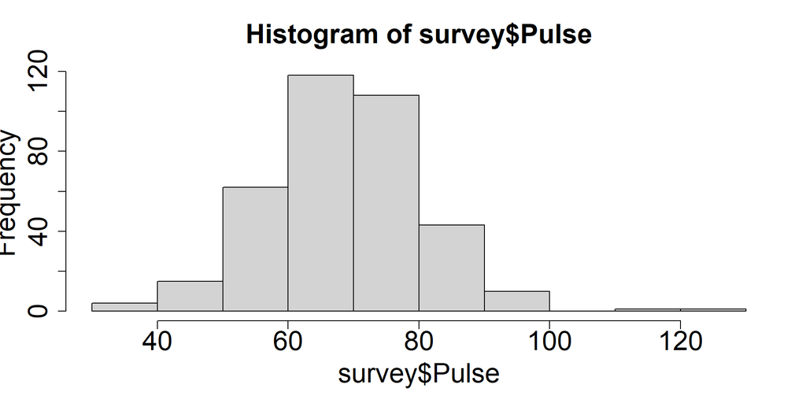

```r
hist(survey$Pulse)
```

- Would you call this symmetric or skewed?
- Pulse rates are **symmetrically** distributed around a rate of about 70 beats per minute.
- Symmetric distributions are “centered” around a mean and median that are roughly the same in value.

## Shape: Histograms and Skew

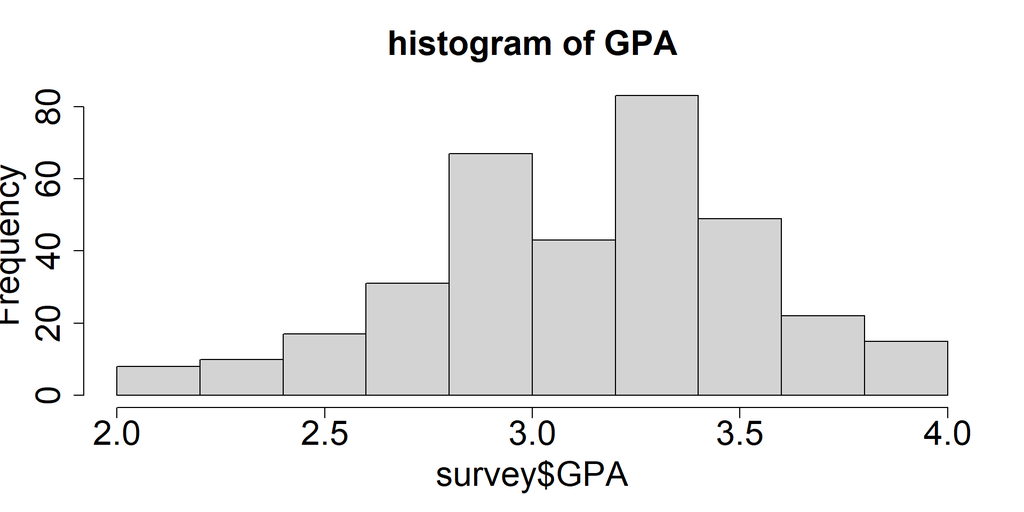

```r
hist(survey$GPA, main = "histogram of GPA")
```

- Would you call this symmetric or skewed?
- GPAs are slightly **left skewed**
- There is a “longer left tail” meaning more variation to the left of center than to the right.
- Mean GPA (3.16) is slightly less than median (3.2)

## Shape: Histograms and Skew

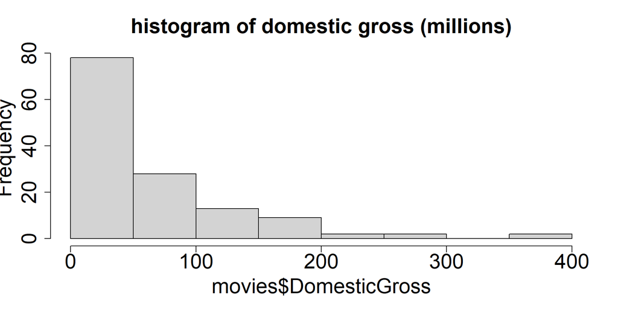

```r
hist(movies$DomesticGross,
    main = "histogram of domestic gross (millions)")
```

- Domestic gross amounts are very **right skewed**.
- There is a “longer right tail” meaning more variation to the right of center than to the left
- Mean domestic gross ($63.2 million) is much greater than median ($37.4 million)

## Shape: Histograms and Skew

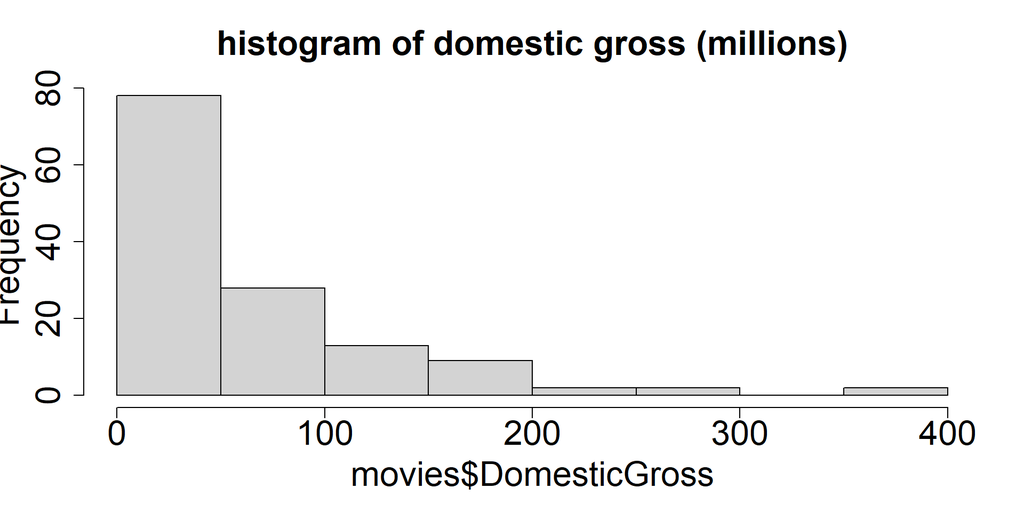

```r
hist(movies$DomesticGross, main = "histogram of domestic gross (millions)")
```

- Why is SD (s=69.4) an inadequate measure of variation for skewed distributions?
- The top half and bottom half of the data have different variability; one number doesn’t sum up the variability well

## Skew and summary statistics?

What does the skew imply about the mean and the median?

- If the dataset is skewed, they will be unequal.

## Extreme Values

**Definition**

**outlier**: an observed value that is notably distinct from most other values in the dataset

**resistant**: a statistic is resistant to outliers if it is relatively unaffected by outliers

- Is the mean or the median resistant?
- Median is resistant to outliers
- Mean and SD are **not** resistant

## Extreme Values

**Example**

Movie domestic gross (millions of dollars) stats with and without Harry Potter movie:

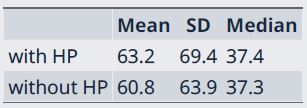

Why does the mean change more than the median when this case is removed?

## Identifying Extreme Values in R

Which movies (cases/rows) have extreme domestic gross values?

- Use the histogram to determine a threshold for “big”
- a value is “big” if DomesticGross > 300
- DomesticGross > 300 is called a logical statement (either TRUE or FALSE)

## Identifying Extreme Values in R

**Example: Using Slice**

- which() identifies the row number of cases that satisfy a given criteria
- then slice() the data frame to only these rows

```r
which(movies$DomesticGross > 300) # gives row number
```

```
[1]  4 14
```

```r
slice(movies, 4, 14)
```

```
                                        Movie          LeadStudio
1 Harry Potter and the Deathly Hallows Part 2         Warner Bros
2              Transformers: Dark of the Moon DreamWorks Pictures
  RottenTomatoes AudienceScore   Story   Genre TheatersOpenWeek
1             96            92 Rivalry Fantasy             4375
2             35            67   Quest  Action             4088
  BOAverageOpenWeek DomesticGross ForeignGross WorldGross Budget
1             38672        381.01       947.10   1328.111    125
2             23937        352.39       770.81   1123.195    195
  Profitability OpeningWeekend
1     10.624888         169.19
2      5.759974          97.85
```

## Identifying Extreme Values in R

**Example: Using Filter**

- filter() the data frame based on our criteria for “big” values:

```r
filter(movies, DomesticGross > 300)
```

```
                                        Movie          LeadStudio
1 Harry Potter and the Deathly Hallows Part 2         Warner Bros
2              Transformers: Dark of the Moon DreamWorks Pictures
  RottenTomatoes AudienceScore   Story   Genre TheatersOpenWeek
1             96            92 Rivalry Fantasy             4375
2             35            67   Quest  Action             4088
  BOAverageOpenWeek DomesticGross ForeignGross WorldGross Budget
1             38672        381.01       947.10   1328.111    125
2             23937        352.39       770.81   1123.195    195
  Profitability OpeningWeekend
1     10.624888         169.19
2      5.759974          97.85
```

## Analyzing Data with Extreme Values

What are the summary stats if we remove Harry Potter and the Deathly Hallows Part 2 (domestic gross about 381)?

1. Create a new version of the data that excludes this case(s)
2. Recompute statistics/graphs
3. **Must report this filtering step**

**Example: Using Filter**

- filter the data frame based on our criteria to only exclude HP (gross of about 381)

```r
movies_noHP <- filter(movies, DomesticGross <= 380)
dim(movies) # full data = 136 rows
```

```
[1] 136  14
```

```r
dim(movies_noHP) # removes HP AND the 2 NA cases!
```

```
[1] 133  14
```

## Analyzing Data with Extreme Values

What are the summary stats if we remove Harry Potter and the Deathly Hallows Part 2 (domestic gross about 381)?

1. Create a new version of the data that excludes this case(s)
2. Recompute statistics/graphs
3. **Must report this filtering step**

**Example: Using Filter**

- Recompute stats (note that the *NA* cases are also removed)

```r
summary(movies_noHP$DomesticGross)
```

```
   Min. 1st Qu.  Median    Mean 3rd Qu.    Max.
   0.02   18.88   37.30   60.83   80.36  352.39
```

```r
sd(movies_noHP$DomesticGross)
```

```
[1] 63.91045
```

# Comparing Distributions

## Comparing Distribution: With `group_by()`

- The group_by function can help us summarize information by categorical variables

```r
survey %>% group_by(HigherSAT) %>%
    summarize(mean(Siblings))
```

```
# A tibble: 3 × 2
  HigherSAT `mean(Siblings)`
  <chr>                <dbl>
1 ""                    1.14
2 "Math"                1.81
3 "Verbal"              1.64
```

## Comparing Distribution: With Plots

- We can compare distributions with histograms of y for separate levels of x.
- In ggplot2, this is done with with faceting
  - draw a geom_histogram for Pulse
  - add facet_wrap for Smoke

## Comparing Distribution: With Plots

**geom_histogram**

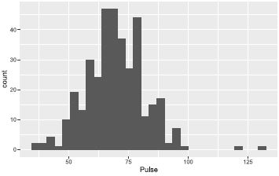

```r
library(ggplot2)
ggplot(survey, aes(x = Pulse)) + geom_histogram()
```

## Comparing Distribution: With Plots

**geom_histogram**

```r
library(ggplot2)
ggplot(survey, aes(x = Pulse)) + geom_histogram()
```

**facet_wrap**

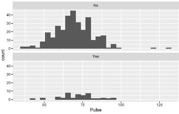

```r
ggplot(survey, aes(x = Pulse)) +  geom_histogram() +
        facet_wrap(~Smoke, nrow = 2)
```

- Non-smokers: symmetric with two notable “outliers”
- Smokers: symmetric
- Smaller sample size of smokers means smaller counts

Practice with Handout. Today’s handout walks you through a lot of the code discussed in today’s class.

We are building towards writing your own commands.

# Wrap Up

## Next Class

- More quantitative exploration
- Boxplots, 95% Rule, Percentiles